# Infografia Final

Rubén Darío Vargas Yandy

6/15/2021

## Introducción

Para la realización de las pruebas, requeridas para respaldar la infografía adjunta a este documento se realizó un preprocesamiento de los datos, para separarlos por medidas de tiempo, dada la facilidad que este tipo de operaciones tiene en lenguajes como Python3, haciendo uso de las librerias para el manejo de conjuntos de datos Pandas, Scikit-Learn y algunas built-in del mismo lenguaje.

El resumen de dicho pre-procesamiento se puede ver directamente en el archivo .ipynb de este directorio, o bien se puede leer su impresión y resumen en pdf, que se encuentra dentro del archivo “pre-procesamiento.pdf”

### Afirmación 1: Los grupos vulnerables siguen siendo los adultos mayores de 60 años en Colombia

Algo que se ha venido repitiendo, por distintos medios de comunicación locales, es que el Coronavirus en 2021, debido a las mutaciones del virus, está afectando más gravemente y en mayor medida a personas más jovenes.

```r
fallecidos_2020 <-read.csv("./out/fallecidos2020.csv")
fallecidos_2021 <-read.csv("./out/fallecidos2021.csv")
```

Para hacer un primer análisis visual, se hace plot de la distribución por edades de los fallecidos

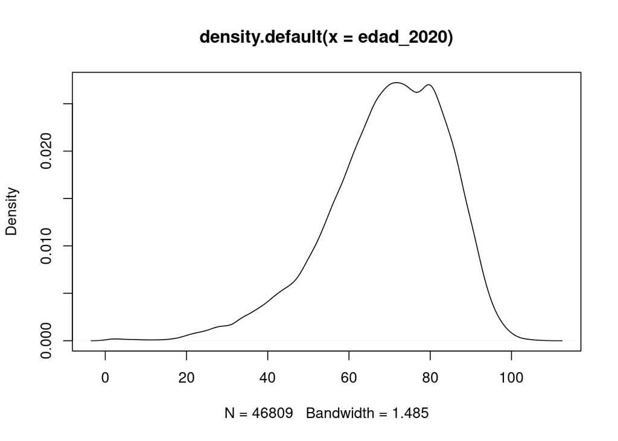

```r
edad_2020 <- as.vector(fallecidos_2020[, "Edad"])
edad_2021 <- as.vector(fallecidos_2021[, "Edad"])

plot(density(edad_2020))
```

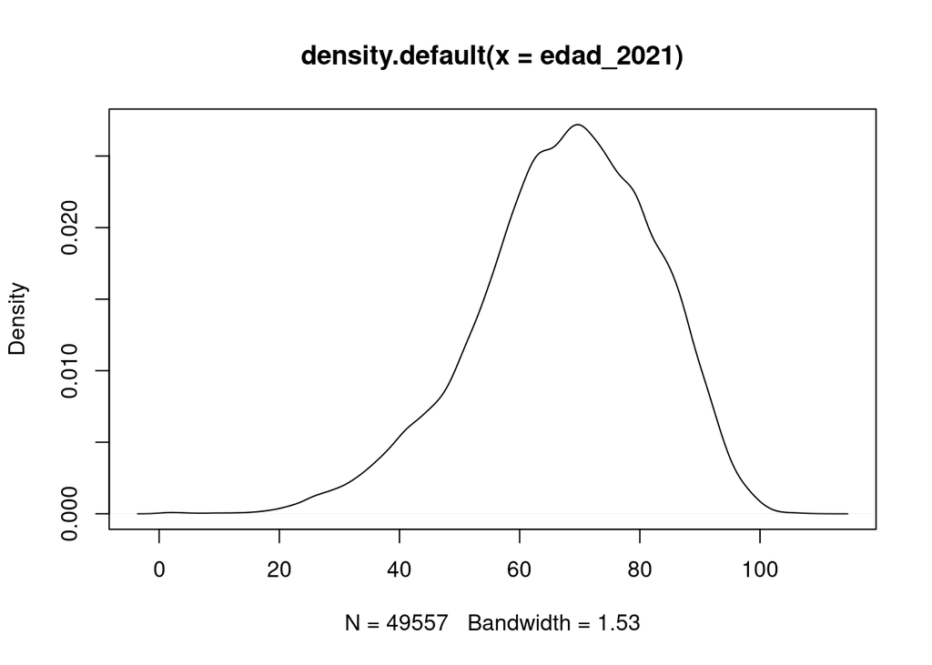

```r
plot(density(edad_2021))
```

Ahora bien, realizamos las pruebas de normalidad, recordemos que estas pruebas toman como la hipotesis nula que las muestras provienen de una distribución normal con las distintas pruebas de normalidad que tiene R

#### Kolmorogov-Smirnov

```r
  ks.test(x=edad_2020,y='pnorm', mean=mean(edad_2020), sd=sd(edad_2020))
```

```
##
##  One-sample Kolmogorov-Smirnov test
##
## data:  edad_2020
## D = 0.05812, p-value < 2.2e-16
## alternative hypothesis: two-sided
```

```r
  ks.test(x=edad_2021,y='pnorm', mean=mean(edad_2021), sd=sd(edad_2021))
```

```
##
##  One-sample Kolmogorov-Smirnov test
##
## data:  edad_2021
## D = 0.041033, p-value < 2.2e-16
## alternative hypothesis: two-sided
```

Como podemos ver, por los resultados de las correspondientes pruebas de normalidad Kolmogorov-Smirnov, el valor de p es menor que 0.05, que por concenso es nuestro nivel de significancia para rechazar o aceptar la hipotesis nula. Si bien en las graficas no eran lo suficientemente claras, la prueba K-S nos desmuestra que no provienen, ninguna de las dos muestras, de una distribución normal.

Esta información es de vital importancia para escoger el tipo de técnica a usar en nuestra siguiente prueba.

#### Definición de la hipotésis

Para afirmar que las personas más afectadas siguen siendo los adultos mayores de 60 años, deberiamos probar que la media de edad de los fallecidos en 2020 es mayor que 60 y que, a su vez, la media de edad de fallecidos en 2021 tambien.

#### Probando que la media de edad en los fallecidos en 2020 es mayor que 60

Como pudimos ver, no tan claramente en las gráficas pero si con la prueba K-S, los datos de las edades de los fallecidos por Covid-19 en ambos años no son distribuciones normales, es por esta razón que utilizamos una prueba de hipotesis no parametrica: Mann-Whiteney-Wilcoxon que en R está predefinida como “wilcox.test”, recordando siempre que el criterio de rechazo de la hipotesis nula es que p-value sea menor que 0.05.

```r
  wilcox.test(edad_2020, mu=60, alternative = "g", paired = F, conf.level = 0.95)
```

```
##
##  Wilcoxon signed rank test with continuity correction
##
## data:  edad_2020
## V = 869431729, p-value < 2.2e-16
## alternative hypothesis: true location is greater than 60
```

La hipotesis nula de la anterior prueba rezaba lo siguiente: La mediana de la población de la muestra es menor o igual que 60, y la hipotesis alternativa que la mediana de la población es mayor a 60, dado que p-value es menor que 0.05 se rechaza la hipotesis nula y se afirma la alternativa, es decir: la mayoría de los fallecidos son mayores de 60 años en el año 2020.

#### Probando que la media de edad en los fallecidos en 2021 es mayor que 60

```r
  wilcox.test(edad_2021, mu=60, alternative = "g", paired = F, conf.level = 0.95)
```

```
##
##  Wilcoxon signed rank test with continuity correction
##
## data:  edad_2021
## V = 908264529, p-value < 2.2e-16
## alternative hypothesis: true location is greater than 60
```

Al igual que en los datos recolectados de los fallecidos por Covid-19 en 2020, los datos de fallecidos por Covid-19 en 2021, nos indican, después de realizar la prueba de hipotesis, que la mayoría de las personas fallecidas son mayores de 60 años.

#### Conclusion de la afirmación en el infograma:

Así pues, al tener comprobado que en ambos años la población más afectada por Covid-19, puesto que fallecieron, fueron los mayores de 60 años, podemos concluir que la población vulnerable sigue siendo esta y no la de los adultos jovenes (menores de 60), como se dice en algunos medios de comunicación y en rumores de redes sociales.

### Afirmación 2: Los contagios y muertes en 2021 se han mantenido o venido en aumento, incluso después del inicio de la vacunación (marzo 2021), en Colombia

Aquí hacemos uso de la base de datos recolectado de manera propia, tomando los tweets de la cuenta oficial del Ministerio de la Salud en Twitter que reportaban los nuevos contagios y fallecidos día a día en Colombia, también pre-procesados en Python3

Empezamos con la lectura de los datos

```r
  reportes_antes_vacunacion <-read.csv("./out/reportes_antes_vacunacion_minsalud.csv")
  reportes_despues_vacunacion <-read.csv("./out/reportes_despues_vacunacion_minsalud.csv")
```

Una breve explicación de las columnas: * recuperados: Número de pacientes diagnosticados con Covid-19 recuperados y registrados ese día * nuevos: Número de nuevas personas diagnosticados con Covid-19 y registrados ese día * fallecidos: Número de personas fallecidas por Covid-19 registrados ese día * muestras: Número de muestras para testear Covid-19 tomadas ese día * date: Fecha de la tomá del reporte

#### Análisis visual previo de los contagios:

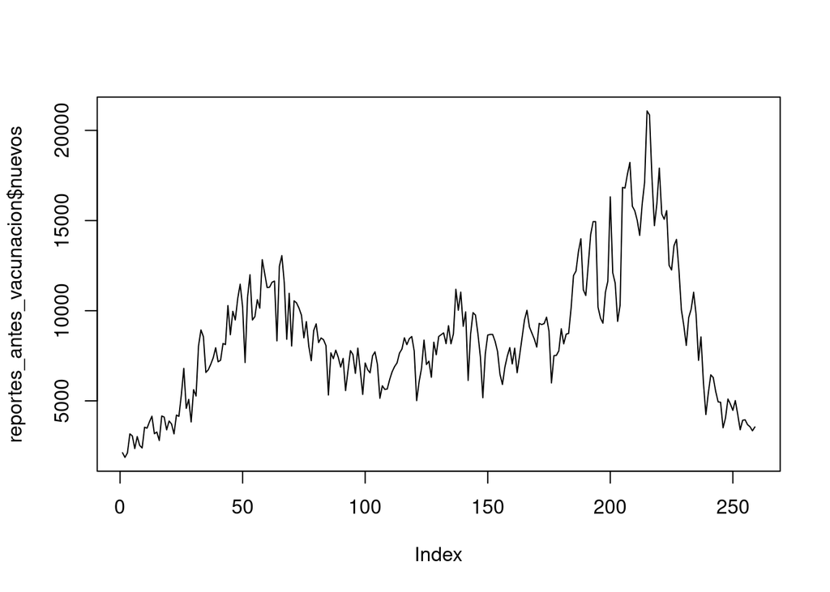

```r
  plot(reportes_antes_vacunacion$nuevos, type="l")
```

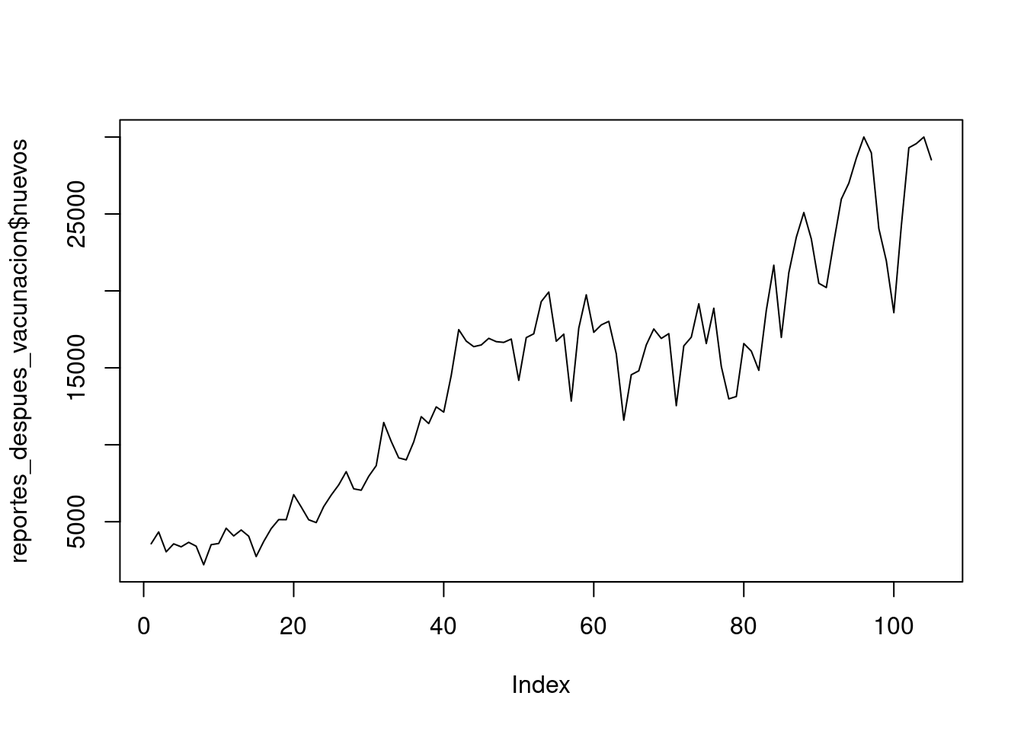

```r
  plot(reportes_despues_vacunacion$nuevos, type="l")
```

### Análisis visual previo de los fallecimientos:

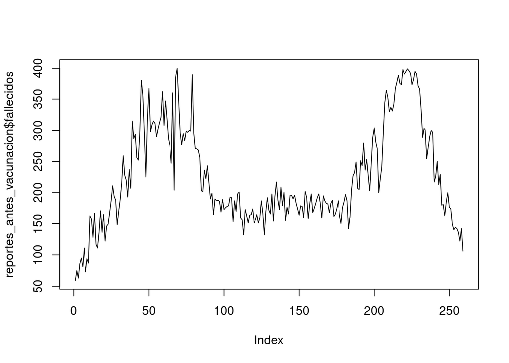

```r
  plot(reportes_antes_vacunacion$fallecidos, type="l")
```

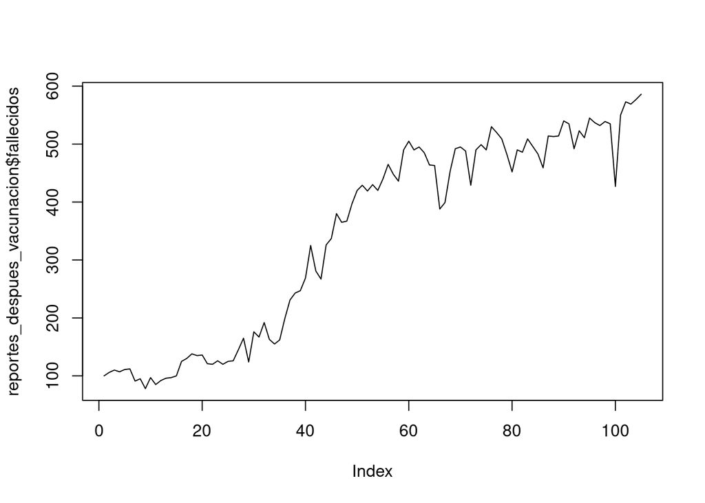

```r
  plot(reportes_despues_vacunacion$fallecidos, type="l")
```

Como se desea demostrar algo sobre los contagios y muertes de los diferentes momentos, se debe dividir dichas hipotesis en 2, una para contagios y otra para muertes.

#### Definicion de hipotesis 1:

¿Han disminuido los contagios desde el inicio de la vacunacion? Podemos traducirlo en probar si en los días anteriores a la vacunación hubo menos contqiados que en los días posteriores, de esto ser cierto, querría decir que en los días posteriores o se mantuvo el ritmo de contagios o aumentó. (Negando la afirmación de que disminuyeron)

#### ¿Que distribución tienen estos datos?

Primero se debe saber que tipo de distribución tienen los datos (contagios por día antes y despues de la vacunación), para escoger una estadística paramétrica adecuada, por lo tanto realizamos la prueba de normalidad Kolmorogov-Smirnov

```r
contagios_antes <-reportes_antes_vacunacion$nuevos
contagios_despues <-reportes_despues_vacunacion$nuevos
ks.test(x=contagios_antes,y='pnorm', mean=mean(contagios_antes), sd=sd(contagios_antes))
```

```
##
##  One-sample Kolmogorov-Smirnov test
##
## data:  contagios_antes
## D = 0.091429, p-value = 0.02633
## alternative hypothesis: two-sided
```

```r
ks.test(x=contagios_despues,y='pnorm', mean=mean(contagios_antes), sd=sd(contagios_despues))
```

```
##
##  One-sample Kolmogorov-Smirnov test
##
## data:  contagios_despues
## D = 0.35103, p-value = 1.157e-11
## alternative hypothesis: two-sided
```

Siendo la hipotesis nula de Kolmorogov-Smirnov que los datos provienen de una distribución normal y p-value < 0.05, está debe ser rechazada, por lo tanto los datos no tienen distribución normal y no pueden ser tratados con técnicas de prueba de hipotesis parametricas.

Por lo anterior se utiliza Wilcoxon (U Mann Whiteney) para probar las hipotesis.

#### Prueba de la hipotesis

```r
nA <- length(contagios_antes)
nD <- length(contagios_despues)
muestras <- c(rep(1, nA), rep(2, nD))
contagios <- c(contagios_antes, contagios_despues)
#Prueba de U Mann-Whitney
wilcox.test(contagios~muestras, paired=F, mu=0, alternative="l", conf.level = "0.95")
```

```
##
##  Wilcoxon rank sum test with continuity correction
##
## data:  contagios by muestras
## W = 7529.5, p-value = 1.268e-11
## alternative hypothesis: true location shift is less than 0
```

El p-value devuelto por esta prueba no-parametrica nos indican que debemos rechazar la hipotesis nula, es decir, podemos concluir que: la mediana de contagios antes del inicio de la vacunación es menor a la mediana de contagiados despues de el inicio de esta. Por lo tanto, la afirmación de que los contagios aumentaron, incluso empezado el plan de vacunación en marzo es verdadera.

#### Definicion de hipotesis 2:

¿Han disminuido las muertes desde el inicio de la vacunacion? Podemos traducirlo en probar si en los días anteriores a la vacunación hubo menos muertos que en los días posteriores, de esto ser cierto, querría decir que en los días posteriores o se mantuvo el ritmo de contagios o aumentó. (Negando la afirmación de que disminuyeron)

#### ¿Que distribución tienen estos datos?

Primero se debe saber que tipo de distribución tienen los datos (fallecidos por día antes y despues de la vacunación), para escoger una estadística paramétrica adecuada, por lo tanto realizamos la prueba de normalidad Kolmorogov-Smirnov

```r
muertos_antes <-reportes_antes_vacunacion$fallecidos
muertos_despues <-reportes_despues_vacunacion$fallecidos
ks.test(x=muertos_antes,y='pnorm', mean=mean(muertos_antes), sd=sd(muertos_antes))
```

```
##
##  One-sample Kolmogorov-Smirnov test
##
## data:  muertos_antes
## D = 0.15701, p-value = 5.691e-06
## alternative hypothesis: two-sided
```

```r
ks.test(x=muertos_despues,y='pnorm', mean=mean(contagios_antes), sd=sd(muertos_despues))
```

```
##
##  One-sample Kolmogorov-Smirnov test
##
## data:  muertos_despues
## D = 1, p-value < 2.2e-16
## alternative hypothesis: two-sided
```

Por lo anterior se utiliza Wilcoxon (U Mann Whiteney) para probar las hipotesis.

#### Prueba de la hipotesis

```r
nA <- length(muertos_antes)
nD <- length(muertos_despues)
muestras <- c(rep(1, nA), rep(2, nD))
muertos <- c(muertos_antes, muertos_despues)
#Prueba de U Mann-Whitney
wilcox.test(muertos~muestras, paired=F, mu=0, alternative="l", conf.level = "0.95")
```

```
##
##  Wilcoxon rank sum test with continuity correction
##
## data:  muertos by muestras
## W = 9071.5, p-value = 3.247e-07
## alternative hypothesis: true location shift is less than 0
```

El p-value devuelto por esta prueba no-parametrica nos indican que debemos rechazar la hipotesis nula, es decir, podemos concluir que: la mediana de muertos antes del inicio de la vacunación es menor a la mediana de muertos despues de el inicio de esta. Por lo tanto, la afirmación de que los muertos por Covid-19 aumentaron, incluso empezado el plan de vacunación en marzo es verdadera.

#### Conclusión de la afirmación en el infograma:

Se probó, mediante pruebas estadísticas que los niveles de contagio (hipotesis 1) y de fallecimientos por Covid-19 (hipotesis 2) eran menores en los días anteriores al inicio de la vacunación (marzo de 2021), es decir se han incrementado los efectos del Covid-19 en Colombia incluso habiendo empezado el plan de vacunación.